# 01-lake-superior-climate-change

## Climate Change Data Analysis using Python

##### Grand Marais, MN weather station (USC00213282) used a land-based proxy for air temperatures near Lake Superior.

### Clean & Wrangle Data

```python
# Import libraries
import earthpy # Manage local data
import pandas as pd #Work with tabular data
```

```python
# Restore variables from downloading data
%store -r grand_marais_raw_climate_df
%store -r grand_marais_ncei_url
```

```python
# Get information on raw data frame
grand_marais_raw_climate_df.info()
```

```
<class 'pandas.core.frame.DataFrame'>
DatetimeIndex: 35921 entries, 1920-03-01 to 2020-12-31
Data columns (total 2 columns):
 #   Column   Non-Null Count  Dtype
---  ------   --------------  -----
 0   STATION  35921 non-null  object
 1   TOBS     34283 non-null  float64
dtypes: float64(1), object(1)
memory usage: 841.9+ KB
```

```python
# Check that data was imported into a pandas DataFrame
type(grand_marais_raw_climate_df)
```

```
pandas.core.frame.DataFrame
```

```python
# Retrieve temperature column only
grand_marais_climate_df = grand_marais_raw_climate_df[["TOBS"]]

# Call data frame with only temp
grand_marais_climate_df
```

| DATE | TOBS |
| --- | --- |
| 1920-03-01 | NaN |
| 1920-03-02 | 16.0 |
| 1920-03-03 | 25.0 |
| 1920-03-04 | 10.0 |
| 1920-03-05 | 12.0 |
| ... | ... |
| 2020-12-27 | 17.0 |
| 2020-12-28 | 15.0 |
| 2020-12-29 | 2.0 |
| 2020-12-30 | 23.0 |
| 2020-12-31 | 10.0 |

35921 rows × 1 columns

```python
# Store variables
%store grand_marais_climate_df grand_marais_raw_climate_df
```

```
Stored 'grand_marais_climate_df' (DataFrame)
Stored 'grand_marais_raw_climate_df' (DataFrame)
```

### Convert units for Grand Marais, MN dataset (proxy for Lake Superior)

```python
# Restore variables from wrangling data section
%store -r grand_marais_climate_df
%store -r grand_marais_raw_climate_df
```

```python
# Rename temp column with units in fahrenheit
grand_marais_climate_df_units = grand_marais_climate_df.rename(columns={
    'TOBS': 'temp_f',
})

# Call data frame with renamed column with f units
grand_marais_climate_df_units
```

| DATE | temp_f |
| --- | --- |
| 1920-03-01 | NaN |
| 1920-03-02 | 16.0 |
| 1920-03-03 | 25.0 |
| 1920-03-04 | 10.0 |
| 1920-03-05 | 12.0 |
| ... | ... |
| 2020-12-27 | 17.0 |
| 2020-12-28 | 15.0 |
| 2020-12-29 | 2.0 |
| 2020-12-30 | 23.0 |
| 2020-12-31 | 10.0 |

35921 rows × 1 columns

```python
# Convert original data frame from farenheight to celsius
grand_marais_climate_df_units['temp_c'] = ((grand_marais_climate_df_units['temp_f']-32)*(5/9))

# Call new data frame with both unit columns
grand_marais_climate_df_units
```

| DATE | temp_f | temp_c |
| --- | --- | --- |
| 1920-03-01 | NaN | NaN |
| 1920-03-02 | 16.0 | -8.888889 |
| 1920-03-03 | 25.0 | -3.888889 |
| 1920-03-04 | 10.0 | -12.222222 |
| 1920-03-05 | 12.0 | -11.111111 |
| ... | ... | ... |
| 2020-12-27 | 17.0 | -8.333333 |
| 2020-12-28 | 15.0 | -9.444444 |
| 2020-12-29 | 2.0 | -16.666667 |
| 2020-12-30 | 23.0 | -5.000000 |
| 2020-12-31 | 10.0 | -12.222222 |

35921 rows × 2 columns

```python
# Convert units with a function
def convert(temp_f):
    """Convert Fahrenheit temperature to Celsius"""
    return (temp_f- 32) *(5/9)

# Naming the celsius conversion column
grand_marais_climate_df_units['temp_c'] = (
    grand_marais_climate_df_units['temp_f'].apply(convert))

# Call converted units table
grand_marais_climate_df_units
```

| DATE | temp_f | temp_c |
| --- | --- | --- |
| 1920-03-01 | NaN | NaN |
| 1920-03-02 | 16.0 | -8.888889 |
| 1920-03-03 | 25.0 | -3.888889 |
| 1920-03-04 | 10.0 | -12.222222 |
| 1920-03-05 | 12.0 | -11.111111 |
| ... | ... | ... |
| 2020-12-27 | 17.0 | -8.333333 |
| 2020-12-28 | 15.0 | -9.444444 |
| 2020-12-29 | 2.0 | -16.666667 |
| 2020-12-30 | 23.0 | -5.000000 |
| 2020-12-31 | 10.0 | -12.222222 |

35921 rows × 2 columns

```python
# Store data frame units for future use
%store grand_marais_climate_df_units
```

```
Stored 'grand_marais_climate_df_units' (DataFrame)
```

### Plot results

```python
%store -r grand_marais_climate_df_units
```

```python
# Import packages
import holoviews as hv
import hvplot.pandas
```

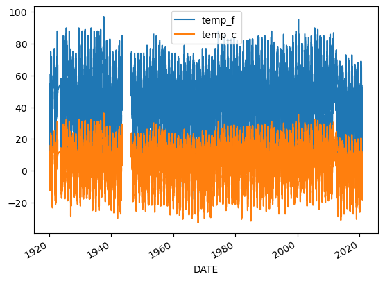

```python
# Plot grand marais temperature data frame
grand_marais_climate_df_units.plot()
```

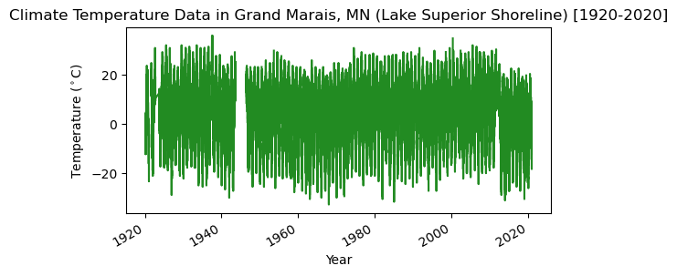

```python
# Plot the data using .plot
grand_marais_climate_df_units.plot(
    y='temp_c',
    title='Climate Temperature Data in Grand Marais, MN (Lake Superior Shoreline) [1920-2020]',
    xlabel='Year',
    ylabel='Temperature ($^\circ$C) ',
    legend=False,
    color='forestgreen',
    figsize= (6, 3))
```

```python
# Clean plot by using average annual temp
grand_marais_ann_temp_df = (
   grand_marais_climate_df_units
   # Date time set to start of year
   .resample('YS')
   # Calculate annual average of temperature data
   .mean()
)

# Call annual temperature data frame
grand_marais_ann_temp_df
```

| DATE | temp_f | temp_c |
| --- | --- | --- |
| 1920-01-01 | 44.000000 | 6.666667 |
| 1921-01-01 | 39.071429 | 3.928571 |
| 1922-01-01 | 41.863469 | 5.479705 |
| 1923-01-01 | 39.141304 | 3.967391 |
| 1924-01-01 | 41.444751 | 5.247084 |
| ... | ... | ... |
| 2016-01-01 | 38.068493 | 3.371385 |
| 2017-01-01 | 36.006006 | 2.225559 |
| 2018-01-01 | 34.049315 | 1.138508 |
| 2019-01-01 | 33.909589 | 1.060883 |
| 2020-01-01 | 35.092262 | 1.717923 |

101 rows × 2 columns

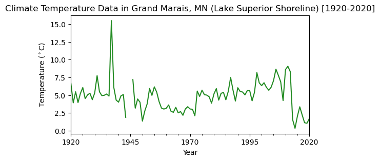

```python
# Plot the annual data
grand_marais_ann_temp_df.plot(
    y='temp_c',
    title='Climate Temperature Data in Grand Marais, MN (Lake Superior Shoreline) [1920-2020]',
    xlabel='Year',
    ylabel='Temperature ($^\circ$C)',
    legend=False,
    color='forestgreen',
    figsize=(6, 3))
```

```python
# Plot the annual data interactively
grand_marais_ann_temp_plot = grand_marais_ann_temp_df.hvplot(
    y='temp_c',
    title='Climate Temperature Data in Grand Marais, MN (Lake Superior Shoreline) [1920-2020]',
    xlabel='Year',
    ylabel='Temperature (°C)',
    legend=False,
    color='forestgreen',
    width=1000,
    height=500)

# Call the interactive temperature plot
grand_marais_ann_temp_plot
```

```python
# Save plot as html
hv.save(grand_marais_ann_temp_plot, 'grand_marais_ann_temp_plot.html')
```

```python
# Store variables for future use
%store grand_marais_ann_temp_plot grand_marais_ann_temp_df
```

```
Stored 'grand_marais_ann_temp_plot' (Curve)
Stored 'grand_marais_ann_temp_df' (DataFrame)
```

### Linear Regression Analysis & Changing Climate

```python
%store -r grand_marais_ann_temp_df
```

```python
# Advanced options on matplotlib/seaborn/pandas plots
import matplotlib.pyplot as plt

# Common statistical plots for tabular data
import seaborn as sns

# Fit an OLS linear regression
from sklearn.linear_model import LinearRegression

# Import pandas for index
import pandas as pd
```

```python
grand_marais_ann_temp_df.index.year.values
```

```
array([1920, 1921, 1922, 1923, 1924, 1925, 1926, 1927, 1928, 1929, 1930,
       1931, 1932, 1933, 1934, 1935, 1936, 1937, 1938, 1939, 1940, 1941,
       1942, 1943, 1944, 1945, 1946, 1947, 1948, 1949, 1950, 1951, 1952,
       1953, 1954, 1955, 1956, 1957, 1958, 1959, 1960, 1961, 1962, 1963,
       1964, 1965, 1966, 1967, 1968, 1969, 1970, 1971, 1972, 1973, 1974,
       1975, 1976, 1977, 1978, 1979, 1980, 1981, 1982, 1983, 1984, 1985,
       1986, 1987, 1988, 1989, 1990, 1991, 1992, 1993, 1994, 1995, 1996,
       1997, 1998, 1999, 2000, 2001, 2002, 2003, 2004, 2005, 2006, 2007,
       2008, 2009, 2010, 2011, 2012, 2013, 2014, 2015, 2016, 2017, 2018,
       2019, 2020], dtype=int32)
```

```python
### This code was created with the help of ChatGPT ###
# Drop rows where 'temp_c' is NaN
grand_marais_temp_clean = grand_marais_ann_temp_df.dropna(subset=['temp_c'])

# Getting the data in the correct format for scikit-learn
X = (
    grand_marais_temp_clean
    # Pull out the year from the date
    .index.year
    # Getting values as arrays using .values
    .values
    #Reshape 'date' column to be a 2D array for scikit-learn
    .reshape(-1, 1))
y = grand_marais_temp_clean['temp_c'].values

# Create and fit the linear regression model
model = LinearRegression()
model.fit(X, y)

# Get the slope and intercept
slope = model.coef_[0]
intercept = model.intercept_

# Print the results
print(f"Slope: {slope}")
print(f"Intercept: {intercept}")
```

```
Slope: -0.001456158897980084
Intercept: 7.709545855066807
```

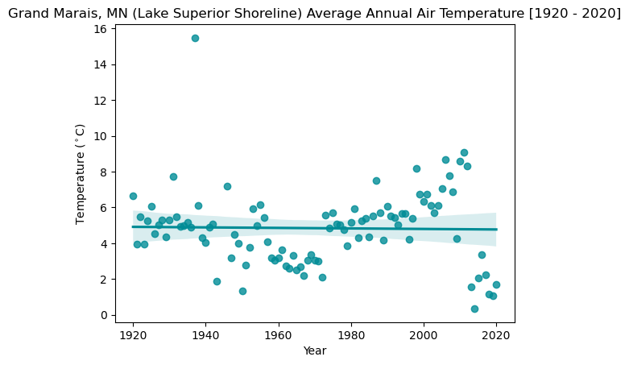

```python
# Plot annual average temperature with a trend line
ax = sns.regplot(
    x=grand_marais_ann_temp_df.index.year,
    y=grand_marais_ann_temp_df.temp_c,
    color='#008C96',
)
# Set plot labels
ax.set(
    title='Grand Marais, MN (Lake Superior Shoreline) Average Annual Air Temperature [1920 - 2020]',
    xlabel='Year',
    ylabel='Temperature ($^\circ$C)'
)
# Display the plot without extra text
plt.show()
```

### Climate Change and Large Freshwater Lakes - Lake Superior Shoreline Case Study

Lake Superior in Minnesota is the largest freshwater lake by surface area in the world and is highly sensitive to the impacts of climate change. It holds approximately 10% of the global fresh surface water and is a valuable water resource.

Fresh surface water resources are important for drinking, recreation, wildlife habitat, global climate regulation, industry, agriculture, biodiversity, ground water recharge, and other ecological cycles. Lake Superior is widely studied, with a large body of scientific research to support this data analysis and exploration.

The scope of the analysis was to use data available through the NOAA CDO tool which has land-based stations available with continuous daily records. A buoy station does not always have long-term continuous data for climate analysis and was not available using this tool. Grand Marais, MN station along the shoreline was used as a land-based proxy to get near-shore lake air temperatures. In this data analysis, I explore the average annual air temperature trends from 1920 - 2020 using python and what they reveal about climate change in the Lake Superior region.

##### Wait, that slope is slightly negative?

##### The air temperatures are actually showing a cooling trend?

##### Does this mean climate change is a myth?

##### Not quite, there’s more to the story.

This linear regression analysis showed a slope of –0.002°C per year, which may suggest a very slight cooling trend, equivalent to about 0.2°C over the past 100 years. This change is so small that it may be within local weather variability rather than indicating a true long-term cooling trend.

This case study is a good example of how lakes and large bodies of water can modulate local air temperature so that there are less significant temperature fluctuations which can impact the warming trends we see compared to other regions. Many large lakes are experiencing [extreme climate events even when local air data may show little impact](https://www.nature.com/articles/s43247-025-02341-x). However, [temperatures in the entire great lakes region and further inland are rising](https://glisa.umich.edu/wp-content/uploads/2022/09/Superior_Prospective_Report_2022.pdf?utm_source=chatgpt.com) as we would expect with climate change; as are [water temperatures in Lake Superior rising faster than local air temperatures](https://agupubs.onlinelibrary.wiley.com/doi/pdf/10.1029/2006GL029021). Lake Superior is one of the fastest warming lakes in the world. Lake Superior is experiencing impacts of climate change, so why the misleading air temperatures?

The trend we see in this analysis shows the complex water-air-land relationship and how climate change can be more complex than one might think. The size of the lake acts as a thermal buffer by absorbing and storing heat; leading to less temperature fluctuations than one might expect, even with climate change. Local weather variability and global climate events like La Nina can also be a factor. A simple linear regression over a shoreline station may show little warming or even slight cooling, but this does not mean the lake or region isn’t experiencing climate change.

Lake Superior is experiencing rising water temperatures, [less ice cover](https://www.epa.gov/climate-indicators/climate-change-indicators-great-lakes-ice-cover?utm_source=chatgpt.com), increasing precipitation, and changing storm patterns leading to things like algal blooms, lower oxygen levels, shoreline erosion, habitat loss, impacts on fish species, and more. This climate temperature data analysis highlights that more research is needed to determine the full effects of climate change on freshwater water resources and managing freshwater ecosystems in the coming decades.

Data analysis with air temperature can offer valuable insight into climate change but must always be considered with context, which is more complex than simple warming temperatures. This analysis on Grand Marais, MN, a shoreline station, is one example of how local variability can mask a broader climate trend. Lake Superior as a case study can help us understand the complex relationships between air, water, land, and climate.

#### References

- Data Citation: Menne, M. J., Durre, I., Korzeniewski, B., McNeill, S., Thomas, K., Yin, X., Anthony, S., Ray, R., Vose, R. S., Gleason, B. E., & Houston, T. G. (2012). Global Historical Climatology Network – Daily (GHCN-Daily), Version 3: Grand Marais, MN (USC00213282), 1920–2020. NOAA National Centers for Environmental Information. https://doi.org/10.7289/V5D21VHZ [Accessed October 4, 2025]
- Great Lakes Integrated Sciences and Assessments (GLISA). (2022). Lake Superior Prospective: Summary of Anticipated Future Climate Conditions. University of Michigan. https://glisa.umich.edu/wp-content/uploads/2022/09/Superior_Prospective_Report_2022.pdf
- U.S. Environmental Protection Agency (EPA). (2024). Climate Change Indicators: Great Lakes Ice Cover. https://www.epa.gov/climate-indicators/climate-change-indicators-great-lakes-ice-cover
- Minnesotans for Clean Water / Minnesota Pollution Control Agency. (n.d.). Climate Change and Minnesota’s Lakes. Retrieved 2025, from https://www.pca.state.mn.us
- Nature Communications Earth & Environment (2025) – Climate change–induced amplification of extreme temperatures in large lakes. https://www.nature.com/articles/s43247-025-02341-x